# MacroStatsGraphsMARKDOWN

Teddy Jorgensen

2024-08-07

## PART ONE ASSEMBLING THE DATA

Load in all relevant and required packages

```r
library(tidyverse)
```

```r
library(ggplot2)
library(sqldf)
library(ggpubr)
library(broom)
library(AICcmodavg)
```

Read in the macroinvertebrates datasheet from the local computer, and add in a singular “1” value for every individual macro(this makes creating some graphs much easier), then upload the land use data

```r
MacrosDraft<-read.csv("/Users/tjorgensen/Desktop/Underwood 2024/DATA - Macros.csv")
MacrosDraft$GraphCount<-rep(1,times=count(MacrosDraft))

SiteData<-read.csv("/Users/tjorgensen/Desktop/Underwood 2024/DATA - SiteData.csv")

J3LandUse<-read.csv("/Users/tjorgensen/Desktop/Underwood 2024/LandUseTables.xlsx - J3.csv")
JMainLandUse<-read.csv("/Users/tjorgensen/Desktop/Underwood 2024/LandUseTables.xlsx - JabezMain.csv")
HBLandUse<-read.csv("/Users/tjorgensen/Desktop/Underwood 2024/LandUseTables.xlsx - HowardsBranch.csv")
ARLandUse<-read.csv("/Users/tjorgensen/Desktop/Underwood 2024/LandUseTables.xlsx - ArthursRun.csv")
CCLandUse<-read.csv("/Users/tjorgensen/Desktop/Underwood 2024/LandUseTables.xlsx - CattailCreek.csv")
CULandUse<-read.csv("/Users/tjorgensen/Desktop/Underwood 2024/LandUseTables.xlsx - CattailCreekUpper.csv")
```

We are interested in three land use metrics: percent pervious surface in watershed, percent vegetated surface in watershed, and percent tree cover in wetland. I use the sqldf package to gather and calculate these (other packages would work but I am most used to SQL language as a GIS user)

```r
J3PerviousPct<-sum(sqldf("select Pct from J3LandUse where Porosity = 'Yes'"))
JMainPerviousPct<-sum(sqldf("SELECT Pct FROM JMainLandUse WHERE Porosity = 'Yes'"))
HBPerviousPct<-sum(sqldf("SELECT Pct FROM HBLandUse WHERE Porosity = 'Yes'"))
ARPerviousPct<-sum(sqldf("SELECT Pct FROM ARLandUse WHERE Porosity = 'Yes'"))
CCPerviousPct<-sum(sqldf("SELECT Pct FROM CCLandUse WHERE Porosity = 'Yes'"))
CUPerviousPct<-sum(sqldf("SELECT Pct FROM CULandUse WHERE Porosity = 'Yes'"))
J3VegPct<-sum(sqldf("SELECT Pct FROM J3LandUse WHERE Vegetated = 'Yes'"))
JMainVegPct<-sum(sqldf("SELECT Pct FROM JMainLandUse WHERE Vegetated = 'Yes'"))
HBVegPct<-sum(sqldf("SELECT Pct FROM HBLandUse WHERE Vegetated = 'Yes'"))
ARVegPct<-sum(sqldf("SELECT Pct FROM ARLandUse WHERE Vegetated = 'Yes'"))
CCVegPct<-sum(sqldf("SELECT Pct FROM CCLandUse WHERE Vegetated = 'Yes'"))
CUVegPct<-sum(sqldf("SELECT Pct FROM CULandUse WHERE Vegetated = 'Yes'"))
J3TreePct<-sum(sqldf("SELECT Pct FROM J3LandUse WHERE TreeCvr = 'Yes'"))
JMainTreePct<-sum(sqldf("SELECT Pct FROM JMainLandUse WHERE TreeCvr = 'Yes'"))
HBTreePct<-sum(sqldf("SELECT Pct FROM HBLandUse WHERE TreeCvr = 'Yes'"))
ARTreePct<-sum(sqldf("SELECT Pct FROM ARLandUse WHERE TreeCvr = 'Yes'"))
CCTreePct<-sum(sqldf("SELECT Pct FROM CCLandUse WHERE TreeCvr = 'Yes'"))
CUTreePct<-sum(sqldf("SELECT Pct FROM CULandUse WHERE TreeCvr = 'Yes'"))
```

Focusing now on manipulating the macroinvertebrates table, I find that the creation of certan data later on will become easier if we give each sampling site its own dataframe

```r
J31Tbl<-data.frame(sqldf("SELECT * FROM MacrosDraft WHERE Site = 'J3' AND SiteNo = '1'"))
J32Tbl<-data.frame(sqldf("SELECT * FROM MacrosDraft WHERE Site = 'J3' AND SiteNo = '2'"))
J33Tbl<-data.frame(sqldf("SELECT * FROM MacrosDraft WHERE Site = 'J3' AND SiteNo = '3'"))
JMain1Tbl<-data.frame(sqldf("SELECT * FROM MacrosDraft WHERE Site = 'J1' AND SiteNo = '1'"))
JMain2Tbl<-data.frame(sqldf("SELECT * FROM MacrosDraft WHERE Site = 'J1' AND SiteNo = '2'"))
JMain3Tbl<-data.frame(sqldf("SELECT * FROM MacrosDraft WHERE Site = 'J1' AND SiteNo = '3'"))
HB1Tbl<-data.frame(sqldf("SELECT * FROM MacrosDraft WHERE Site = 'HB' AND SiteNo = '1'"))
HB2Tbl<-data.frame(sqldf("SELECT * FROM MacrosDraft WHERE Site = 'HB' AND SiteNo = '2'"))
HB3Tbl<-data.frame(sqldf("SELECT * FROM MacrosDraft WHERE Site = 'HB' AND SiteNo = '3'"))
AR1Tbl<-data.frame(sqldf("SELECT * FROM MacrosDraft WHERE Site = 'AR' AND SiteNo = '1'"))
AR2Tbl<-data.frame(sqldf("SELECT * FROM MacrosDraft WHERE Site = 'AR' AND SiteNo = '2'"))
AR3Tbl<-data.frame(sqldf("SELECT * FROM MacrosDraft WHERE Site = 'AR' AND SiteNo = '3'"))
CC1Tbl<-data.frame(sqldf("SELECT * FROM MacrosDraft WHERE Site = 'CC' AND SiteNo = '1'"))
CC2Tbl<-data.frame(sqldf("SELECT * FROM MacrosDraft WHERE Site = 'CC' AND SiteNo = '2'"))
CC3Tbl<-data.frame(sqldf("SELECT * FROM MacrosDraft WHERE Site = 'CC' AND SiteNo = '3'"))
CU1Tbl<-data.frame(sqldf("SELECT * FROM MacrosDraft WHERE Site = 'CU' AND SiteNo = '1'"))
CU2Tbl<-data.frame(sqldf("SELECT * FROM MacrosDraft WHERE Site = 'CU' AND SiteNo = '2'"))
CU3Tbl<-data.frame(sqldf("SELECT * FROM MacrosDraft WHERE Site = 'CU' AND SiteNo = '3'"))
```

Create the table that will be used for our statistical calculations- one where a series of dependent and independent variables are grouped under the key attribute of sampling site

```r
SiteName<-c('Jabez 3.1','Jabez 3.2','Jabez 3.3',
            'Jabez Main.1','Jabez Main.2','Jabez Main.3',
            'Howards Branch.1','Howards Branch.2','Howards Branch.3',
            'Arthurs Run.1','Arthurs Run.2','Arthurs Run.3',
            'Cattail Creek Lower.1','Cattail Creek Lower.2','Cattail Creek Lower.3',
            'Cattail Creek Upper.1','Cattail Creek Upper.2','Cattail Creek Upper.3')
Restored<-c(rep(TRUE,times=3),rep(FALSE,times=3),rep(TRUE,times=3),
           rep(FALSE,times=3),rep(TRUE,times=3),rep(FALSE,times=3))
Habitat<-c("R","V","R","U","R","U","R","V","R","L","L","L","R","R","V","U","U","V")
PerviousPct<-c(rep(J3PerviousPct,times=3),rep(JMainPerviousPct,times=3),rep(HBPerviousPct,times=3),
               rep(ARPerviousPct,times=3),rep(CCPerviousPct,times=3),rep(CUPerviousPct,times=3))
VegPct<-c(rep(J3VegPct,times=3),rep(JMainVegPct,times=3),rep(HBVegPct,times=3),
               rep(ARVegPct,times=3),rep(CCVegPct,times=3),rep(CUVegPct,times=3))
TreePct<-c(rep(J3TreePct,times=3),rep(JMainTreePct,times=3),rep(HBTreePct,times=3),
               rep(ARTreePct,times=3),rep(CCTreePct,times=3),rep(CUTreePct,times=3))
Size<-c(rep(3032553,times=3),rep(10389250,times=3),rep(948410,times=3),
        rep(428450,times=3),rep(6373450,times=3),rep(4471850,times=3))
FlowRate<-c(rep(0.00894*1000000,times=3),rep(0.07565*1000000,times=3),rep(0.00533*1000000,times=3),
            rep(0.00294*1000000,times=3),rep(0.04446*1000000,times=3),rep(0.02798*1000000,times=3))
MacroTally<-c(sum(J31Tbl$GraphCount),sum(J32Tbl$GraphCount),sum(J33Tbl$GraphCount),
             sum(JMain1Tbl$GraphCount),sum(JMain2Tbl$GraphCount),sum(JMain3Tbl$GraphCount),
             sum(HB1Tbl$GraphCount),sum(HB2Tbl$GraphCount),sum(HB3Tbl$GraphCount),
             sum(AR1Tbl$GraphCount),sum(AR2Tbl$GraphCount),sum(AR3Tbl$GraphCount),
             sum(CC1Tbl$GraphCount),sum(CC2Tbl$GraphCount),sum(CC3Tbl$GraphCount),
             sum(CU1Tbl$GraphCount),sum(CU2Tbl$GraphCount),sum(CU3Tbl$GraphCount))
TotalMass<-c(sum(J31Tbl$Weight,na.rm = TRUE),sum(J32Tbl$Weight,na.rm = TRUE),sum(J33Tbl$Weight,na.rm = TRUE),
             sum(JMain1Tbl$Weight,na.rm = TRUE),sum(JMain2Tbl$Weight,na.rm = TRUE),sum(JMain3Tbl$Weight,na.rm = TRUE),
             sum(HB1Tbl$Weight,na.rm = TRUE),sum(HB2Tbl$Weight,na.rm = TRUE),sum(HB3Tbl$Weight,na.rm = TRUE),
             sum(AR1Tbl$Weight,na.rm = TRUE),sum(AR2Tbl$Weight,na.rm = TRUE),sum(AR3Tbl$Weight,na.rm = TRUE),
             sum(CC1Tbl$Weight,na.rm = TRUE),sum(CC2Tbl$Weight,na.rm = TRUE),sum(CC3Tbl$Weight,na.rm = TRUE),
             sum(CU1Tbl$Weight,na.rm = TRUE),sum(CU2Tbl$Weight,na.rm = TRUE),sum(CU3Tbl$Weight,na.rm = TRUE))
EPTAsPct<-c((sum(sqldf("SELECT GraphCount FROM MacrosDraft WHERE Site = 'J3' AND SiteNo = '1' AND TaxOrder = 'Ephemeroptera' OR Site = 'J3' AND SiteNo = '1' AND TaxOrder = 'Plecoptera' OR Site = 'J3' AND SiteNo = '1' AND TaxOrder = 'Trichoptera'"))/sum(sqldf("SELECT GraphCount FROM MacrosDraft WHERE Site = 'J3' AND SiteNo = '1' ")))*100,
            (sum(sqldf("SELECT GraphCount FROM MacrosDraft WHERE Site = 'J3' AND SiteNo = '2' AND TaxOrder = 'Ephemeroptera' OR Site = 'J3' AND SiteNo = '2' AND TaxOrder = 'Plecoptera' OR Site = 'J3' AND SiteNo = '2' AND TaxOrder = 'Trichoptera'"))/sum(sqldf("SELECT GraphCount FROM MacrosDraft WHERE Site = 'J3' AND SiteNo = '2' ")))*100,
            (sum(sqldf("SELECT GraphCount FROM MacrosDraft WHERE Site = 'J3' AND SiteNo = '3' AND TaxOrder = 'Ephemeroptera' OR Site = 'J3' AND SiteNo = '3' AND TaxOrder = 'Plecoptera' OR Site = 'J3' AND SiteNo = '3' AND TaxOrder = 'Trichoptera'"))/sum(sqldf("SELECT GraphCount FROM MacrosDraft WHERE Site = 'J3' AND SiteNo = '3' ")))*100,
            (sum(sqldf("SELECT GraphCount FROM MacrosDraft WHERE Site = 'J1' AND SiteNo = '1' AND TaxOrder = 'Ephemeroptera' OR Site = 'J1' AND SiteNo = '1' AND TaxOrder = 'Plecoptera' OR Site = 'J1' AND SiteNo = '1' AND TaxOrder = 'Trichoptera'"))/sum(sqldf("SELECT GraphCount FROM MacrosDraft WHERE Site = 'J1' AND SiteNo = '1' ")))*100,
            (sum(sqldf("SELECT GraphCount FROM MacrosDraft WHERE Site = 'J1' AND SiteNo = '2' AND TaxOrder = 'Ephemeroptera' OR Site = 'J1' AND SiteNo = '2' AND TaxOrder = 'Plecoptera' OR Site = 'J1' AND SiteNo = '2' AND TaxOrder = 'Trichoptera'"))/sum(sqldf("SELECT GraphCount FROM MacrosDraft WHERE Site = 'J1' AND SiteNo = '2' ")))*100,
            (sum(sqldf("SELECT GraphCount FROM MacrosDraft WHERE Site = 'J1' AND SiteNo = '3' AND TaxOrder = 'Ephemeroptera' OR Site = 'J1' AND SiteNo = '3' AND TaxOrder = 'Plecoptera' OR Site = 'J1' AND SiteNo = '3' AND TaxOrder = 'Trichoptera'"))/sum(sqldf("SELECT GraphCount FROM MacrosDraft WHERE Site = 'J1' AND SiteNo = '3' ")))*100,
            (sum(sqldf("SELECT GraphCount FROM MacrosDraft WHERE Site = 'HB' AND SiteNo = '1' AND TaxOrder = 'Ephemeroptera' OR Site = 'HB' AND SiteNo = '1' AND TaxOrder = 'Plecoptera' OR Site = 'HB' AND SiteNo = '1' AND TaxOrder = 'Trichoptera'"))/sum(sqldf("SELECT GraphCount FROM MacrosDraft WHERE Site = 'HB' AND SiteNo = '1' ")))*100,
            (sum(sqldf("SELECT GraphCount FROM MacrosDraft WHERE Site = 'HB' AND SiteNo = '2' AND TaxOrder = 'Ephemeroptera' OR Site = 'HB' AND SiteNo = '2' AND TaxOrder = 'Plecoptera' OR Site = 'HB' AND SiteNo = '2' AND TaxOrder = 'Trichoptera'"))/sum(sqldf("SELECT GraphCount FROM MacrosDraft WHERE Site = 'HB' AND SiteNo = '2' ")))*100,
            (sum(sqldf("SELECT GraphCount FROM MacrosDraft WHERE Site = 'HB' AND SiteNo = '3' AND TaxOrder = 'Ephemeroptera' OR Site = 'HB' AND SiteNo = '3' AND TaxOrder = 'Plecoptera' OR Site = 'HB' AND SiteNo = '3' AND TaxOrder = 'Trichoptera'"))/sum(sqldf("SELECT GraphCount FROM MacrosDraft WHERE Site = 'HB' AND SiteNo = '3' ")))*100,
            (sum(sqldf("SELECT GraphCount FROM MacrosDraft WHERE Site = 'AR' AND SiteNo = '1' AND TaxOrder = 'Ephemeroptera' OR Site = 'AR' AND SiteNo = '1' AND TaxOrder = 'Plecoptera' OR Site = 'AR' AND SiteNo = '1' AND TaxOrder = 'Trichoptera'"))/sum(sqldf("SELECT GraphCount FROM MacrosDraft WHERE Site = 'AR' AND SiteNo = '1' ")))*100,
            (sum(sqldf("SELECT GraphCount FROM MacrosDraft WHERE Site = 'AR' AND SiteNo = '2' AND TaxOrder = 'Ephemeroptera' OR Site = 'AR' AND SiteNo = '2' AND TaxOrder = 'Plecoptera' OR Site = 'AR' AND SiteNo = '2' AND TaxOrder = 'Trichoptera'"))/sum(sqldf("SELECT GraphCount FROM MacrosDraft WHERE Site = 'AR' AND SiteNo = '2' ")))*100,
            (sum(sqldf("SELECT GraphCount FROM MacrosDraft WHERE Site = 'AR' AND SiteNo = '3' AND TaxOrder = 'Ephemeroptera' OR Site = 'AR' AND SiteNo = '3' AND TaxOrder = 'Plecoptera' OR Site = 'AR' AND SiteNo = '3' AND TaxOrder = 'Trichoptera'"))/sum(sqldf("SELECT GraphCount FROM MacrosDraft WHERE Site = 'AR' AND SiteNo = '3' ")))*100,
            (sum(sqldf("SELECT GraphCount FROM MacrosDraft WHERE Site = 'CC' AND SiteNo = '1' AND TaxOrder = 'Ephemeroptera' OR Site = 'CC' AND SiteNo = '1' AND TaxOrder = 'Plecoptera' OR Site = 'CC' AND SiteNo = '1' AND TaxOrder = 'Trichoptera'"))/sum(sqldf("SELECT GraphCount FROM MacrosDraft WHERE Site = 'CC' AND SiteNo = '1' ")))*100,
            (sum(sqldf("SELECT GraphCount FROM MacrosDraft WHERE Site = 'CC' AND SiteNo = '2' AND TaxOrder = 'Ephemeroptera' OR Site = 'CC' AND SiteNo = '2' AND TaxOrder = 'Plecoptera' OR Site = 'CC' AND SiteNo = '2' AND TaxOrder = 'Trichoptera'"))/sum(sqldf("SELECT GraphCount FROM MacrosDraft WHERE Site = 'CC' AND SiteNo = '2' ")))*100,
            (sum(sqldf("SELECT GraphCount FROM MacrosDraft WHERE Site = 'CC' AND SiteNo = '3' AND TaxOrder = 'Ephemeroptera' OR Site = 'CC' AND SiteNo = '3' AND TaxOrder = 'Plecoptera' OR Site = 'CC' AND SiteNo = '3' AND TaxOrder = 'Trichoptera'"))/sum(sqldf("SELECT GraphCount FROM MacrosDraft WHERE Site = 'CC' AND SiteNo = '3' ")))*100,
            (sum(sqldf("SELECT GraphCount FROM MacrosDraft WHERE Site = 'CU' AND SiteNo = '1' AND TaxOrder = 'Ephemeroptera' OR Site = 'CU' AND SiteNo = '1' AND TaxOrder = 'Plecoptera' OR Site = 'CU' AND SiteNo = '1' AND TaxOrder = 'Trichoptera'"))/sum(sqldf("SELECT GraphCount FROM MacrosDraft WHERE Site = 'CU' AND SiteNo = '1' ")))*100,
            (sum(sqldf("SELECT GraphCount FROM MacrosDraft WHERE Site = 'CU' AND SiteNo = '2' AND TaxOrder = 'Ephemeroptera' OR Site = 'CU' AND SiteNo = '2' AND TaxOrder = 'Plecoptera' OR Site = 'CU' AND SiteNo = '2' AND TaxOrder = 'Trichoptera'"))/sum(sqldf("SELECT GraphCount FROM MacrosDraft WHERE Site = 'CU' AND SiteNo = '2' ")))*100,
            (sum(sqldf("SELECT GraphCount FROM MacrosDraft WHERE Site = 'CU' AND SiteNo = '3' AND TaxOrder = 'Ephemeroptera' OR Site = 'CU' AND SiteNo = '3' AND TaxOrder = 'Plecoptera' OR Site = 'CU' AND SiteNo = '3' AND TaxOrder = 'Trichoptera'"))/sum(sqldf("SELECT GraphCount FROM MacrosDraft WHERE Site = 'CU' AND SiteNo = '3' ")))*100)

FinalDataFrameHABITAT<-data.frame(SiteName,Restored,Habitat,Size,FlowRate)
FinalDataFrameHABITAT$DO<-SiteData$DO
FinalDataFrameHABITAT$Temperature<-SiteData$Temp
FinalDataFrameHABITAT$Conductivity<-SiteData$Cond
FinalDataFrameHABITAT$PebbleSize<-((SiteData$PblCountL+SiteData$PblCountW+SiteData$PblCountD)/3)
FinalDataFrameHABITAT$PerviousPct<-PerviousPct
FinalDataFrameHABITAT$VegPct<-VegPct
FinalDataFrameHABITAT$TreePct<-TreePct
FinalDataFrameHABITAT$Date<-SiteData$Date
FinalDataFrameHABITAT$MacroTally<-MacroTally
FinalDataFrameHABITAT$TotalMass<-TotalMass
FinalDataFrameHABITAT$EPTAsPct<-EPTAsPct
TaxaCount <- MacrosDraft %>%
  pivot_longer(Family) %>%
  count(name, value)
print(TaxaCount)
```

```
## # A tibble: 24 × 3
##    name   value                 n
##    <chr>  <chr>             <int>
##  1 Family "\"Stringy\""        11
##  2 Family "Aeshnidae"           1
##  3 Family "Belostomatidae"      1
##  4 Family "Calopterygidae"      1
##  5 Family "Ceratopogonidae"     6
##  6 Family "Chironomidae"      451
##  7 Family "Culicidae"          68
##  8 Family "Elmidae"            16
##  9 Family "Ephemeroptera"      20
## 10 Family "Gammaridae"        157
## # ℹ 14 more rows
```

```r
data.frame(TaxaCount)
```

```
##      name                    value   n
## 1  Family                "Stringy"  11
## 2  Family                Aeshnidae   1
## 3  Family           Belostomatidae   1
## 4  Family           Calopterygidae   1
## 5  Family          Ceratopogonidae   6
## 6  Family             Chironomidae 451
## 7  Family                Culicidae  68
## 8  Family                  Elmidae  16
## 9  Family            Ephemeroptera  20
## 10 Family               Gammaridae 157
## 11 Family          Glossiphoniidae   2
## 12 Family          Glossosomatidae   2
## 13 Family           Hydropsychidae  83
## 14 Family               Limoniidae   1
## 15 Family              Oligochaeta   6
## 16 Family               Perlodidae   1
## 17 Family          Platyhelminthes   1
## 18 Family           Ptychopteridae   2
## 19 Family               Simuliidae   2
## 20 Family              Sphaeriidae  12
## 21 Family                 Unionida   1
## 22 Family Unk. "segmented" species   7
## 23 Family                  Unknown   2
## 24 Family                 Vellidae   2
```

```r
J31TaxaCount <- J31Tbl %>%
  pivot_longer(Family) %>%
  count(name, value)
data.frame(J31TaxaCount)
```

```
##     name           value  n
## 1 Family Ceratopogonidae  1
## 2 Family    Chironomidae 31
## 3 Family       Culicidae  4
## 4 Family   Ephemeroptera  1
## 5 Family      Simuliidae  1
## 6 Family         Unknown  1
```

```r
J32TaxaCount <- J32Tbl %>%
  pivot_longer(Family) %>%
  count(name, value)
data.frame(J32TaxaCount)
```

```
##     name           value  n
## 1 Family Ceratopogonidae  2
## 2 Family    Chironomidae 41
## 3 Family       Culicidae 63
## 4 Family   Ephemeroptera  1
```

```r
J33TaxaCount <- J33Tbl %>%
  pivot_longer(Family) %>%
  count(name, value)
data.frame(J33TaxaCount)
```

```
##     name                    value   n
## 1 Family             Chironomidae 151
## 2 Family                  Elmidae   1
## 3 Family            Ephemeroptera  15
## 4 Family               Simuliidae   1
## 5 Family Unk. "segmented" species   2
```

```r
JMain1TaxaCount <- JMain1Tbl %>%
  pivot_longer(Family) %>%
  count(name, value)
data.frame(JMain1TaxaCount)
```

```
##     name         value  n
## 1 Family  Chironomidae 16
## 2 Family Ephemeroptera  3
```

```r
JMain2TaxaCount <- JMain2Tbl %>%
  pivot_longer(Family) %>%
  count(name, value)
data.frame(JMain2TaxaCount)
```

```
##     name        value n
## 1 Family Chironomidae 4
## 2 Family      Elmidae 1
```

```r
JMain3TaxaCount <- JMain3Tbl %>%
  pivot_longer(Family) %>%
  count(name, value)
data.frame(JMain3TaxaCount)
```

```
##     name      value n
## 1 Family  Culicidae 1
## 2 Family Limoniidae 1
## 3 Family   Vellidae 2
```

```r
HB1TaxaCount <- HB1Tbl %>%
  pivot_longer(Family) %>%
  count(name, value)
data.frame(HB1TaxaCount)
```

```
##     name           value  n
## 1 Family Ceratopogonidae  2
## 2 Family    Chironomidae 15
## 3 Family      Gammaridae 38
## 4 Family     Sphaeriidae  3
```

```r
HB2TaxaCount <- HB2Tbl %>%
  pivot_longer(Family) %>%
  count(name, value)
data.frame(HB2TaxaCount)
```

```
##     name           value  n
## 1 Family    Chironomidae 10
## 2 Family Glossiphoniidae  2
## 3 Family     Sphaeriidae  1
```

```r
HB3TaxaCount <- HB3Tbl %>%
  pivot_longer(Family) %>%
  count(name, value)
data.frame(HB3TaxaCount)
```

```
##     name                    value n
## 1 Family             Chironomidae 6
## 2 Family               Gammaridae 1
## 3 Family              Oligochaeta 1
## 4 Family           Ptychopteridae 2
## 5 Family              Sphaeriidae 3
## 6 Family Unk. "segmented" species 1
## 7 Family                  Unknown 1
```

```r
AR1TaxaCount <- AR1Tbl %>%
  pivot_longer(Family) %>%
  count(name, value)
data.frame(AR1TaxaCount)
```

```
##     name        value n
## 1 Family Chironomidae 8
```

```r
AR2TaxaCount <- AR2Tbl %>%
  pivot_longer(Family) %>%
  count(name, value)
data.frame(AR2TaxaCount)
```

```
##     name        value n
## 1 Family Chironomidae 3
## 2 Family   Perlodidae 1
```

```r
AR3TaxaCount <- AR3Tbl %>%
  pivot_longer(Family) %>%
  count(name, value)
data.frame(AR3TaxaCount)
```

```
##     name        value n
## 1 Family Chironomidae 6
```

```r
CC1TaxaCount <- CC1Tbl %>%
  pivot_longer(Family) %>%
  count(name, value)
data.frame(CC1TaxaCount)
```

```
##     name                    value   n
## 1 Family                "Stringy"  11
## 2 Family          Ceratopogonidae   1
## 3 Family             Chironomidae 106
## 4 Family                 Unionida   1
## 5 Family Unk. "segmented" species   1
```

```r
CC2TaxaCount <- CC2Tbl %>%
  pivot_longer(Family) %>%
  count(name, value)
data.frame(CC2TaxaCount)
```

```
##     name           value n
## 1 Family    Chironomidae 8
## 2 Family         Elmidae 8
## 3 Family      Gammaridae 6
## 4 Family  Hydropsychidae 3
## 5 Family Platyhelminthes 1
```

```r
CC3TaxaCount <- CC3Tbl %>%
  pivot_longer(Family) %>%
  count(name, value)
data.frame(CC3TaxaCount)
```

```
##     name          value n
## 1 Family Belostomatidae 1
## 2 Family   Chironomidae 2
## 3 Family        Elmidae 2
```

```r
CU1TaxaCount <- CU1Tbl %>%
  pivot_longer(Family) %>%
  count(name, value)
data.frame(CU1TaxaCount)
```

```
##     name          value  n
## 1 Family Calopterygidae  1
## 2 Family   Chironomidae  6
## 3 Family        Elmidae  1
## 4 Family     Gammaridae 59
## 5 Family    Oligochaeta  3
## 6 Family    Sphaeriidae  2
```

```r
CU2TaxaCount <- CU2Tbl %>%
  pivot_longer(Family) %>%
  count(name, value)
data.frame(CU2TaxaCount)
```

```
##     name                    value  n
## 1 Family             Chironomidae  2
## 2 Family               Gammaridae 16
## 3 Family              Oligochaeta  1
## 4 Family              Sphaeriidae  3
## 5 Family Unk. "segmented" species  3
```

```r
CU3TaxaCount <- CU3Tbl %>%
  pivot_longer(Family) %>%
  count(name, value)
data.frame(CU3TaxaCount)
```

```
##     name           value  n
## 1 Family       Aeshnidae  1
## 2 Family    Chironomidae 36
## 3 Family         Elmidae  3
## 4 Family      Gammaridae 37
## 5 Family Glossosomatidae  2
## 6 Family  Hydropsychidae 80
## 7 Family     Oligochaeta  1
```

```r
FinalDataFrameHABITAT$NumTaxa<- c(count(J31TaxaCount),count(J32TaxaCount),count(J33TaxaCount),
                                  count(JMain1TaxaCount),count(JMain2TaxaCount),count(JMain3TaxaCount),
                                  count(HB1TaxaCount),count(HB2TaxaCount),count(HB3TaxaCount),
                                  count(AR1TaxaCount),count(AR2TaxaCount),count(AR3TaxaCount),
                                  count(CC1TaxaCount),count(CC2TaxaCount),count(CC3TaxaCount),
                                  count(CU1TaxaCount),count(CU2TaxaCount),count(CU3TaxaCount))
J31Shannon<- -sum((J31TaxaCount$n/sum(J31TaxaCount$n))*log((J31TaxaCount$n/sum(J31TaxaCount$n))))
J32Shannon<- -sum((J32TaxaCount$n/sum(J32TaxaCount$n))*log((J32TaxaCount$n/sum(J32TaxaCount$n))))
J33Shannon<- -sum((J33TaxaCount$n/sum(J33TaxaCount$n))*log((J33TaxaCount$n/sum(J33TaxaCount$n))))
JMain1Shannon<- -sum((JMain1TaxaCount$n/sum(JMain1TaxaCount$n))*log((JMain1TaxaCount$n/sum(JMain1TaxaCount$n))))
JMain2Shannon<- -sum((JMain2TaxaCount$n/sum(JMain2TaxaCount$n))*log((JMain2TaxaCount$n/sum(JMain2TaxaCount$n))))
JMain3Shannon<- -sum((JMain3TaxaCount$n/sum(JMain3TaxaCount$n))*log((JMain3TaxaCount$n/sum(JMain3TaxaCount$n))))
HB1Shannon<- -sum((HB1TaxaCount$n/sum(HB1TaxaCount$n))*log((HB1TaxaCount$n/sum(HB1TaxaCount$n))))
HB2Shannon<- -sum((HB2TaxaCount$n/sum(HB2TaxaCount$n))*log((HB2TaxaCount$n/sum(HB2TaxaCount$n))))
HB3Shannon<- -sum((HB3TaxaCount$n/sum(HB3TaxaCount$n))*log((HB3TaxaCount$n/sum(HB3TaxaCount$n))))
AR1Shannon<- -sum((AR1TaxaCount$n/sum(AR1TaxaCount$n))*log((AR1TaxaCount$n/sum(AR1TaxaCount$n))))
AR2Shannon<- -sum((AR2TaxaCount$n/sum(AR2TaxaCount$n))*log((AR2TaxaCount$n/sum(AR2TaxaCount$n))))
AR3Shannon<- -sum((AR3TaxaCount$n/sum(AR3TaxaCount$n))*log((AR3TaxaCount$n/sum(AR3TaxaCount$n))))
CC1Shannon<- -sum((CC1TaxaCount$n/sum(CC1TaxaCount$n))*log((CC1TaxaCount$n/sum(CC1TaxaCount$n))))
CC2Shannon<- -sum((CC2TaxaCount$n/sum(CC2TaxaCount$n))*log((CC2TaxaCount$n/sum(CC2TaxaCount$n))))
CC3Shannon<- -sum((CC3TaxaCount$n/sum(CC3TaxaCount$n))*log((CC3TaxaCount$n/sum(CC3TaxaCount$n))))
CU1Shannon<- -sum((CU1TaxaCount$n/sum(CU1TaxaCount$n))*log((CU1TaxaCount$n/sum(CU1TaxaCount$n))))
CU2Shannon<- -sum((CU2TaxaCount$n/sum(CU2TaxaCount$n))*log((CU2TaxaCount$n/sum(CU2TaxaCount$n))))
CU3Shannon<- -sum((CU3TaxaCount$n/sum(CU3TaxaCount$n))*log((CU3TaxaCount$n/sum(CU3TaxaCount$n))))
FinalDataFrameHABITAT$ShannonDiversity<- c(J31Shannon,J32Shannon,J33Shannon,JMain1Shannon,JMain2Shannon,JMain3Shannon,HB1Shannon,HB2Shannon,HB3Shannon,AR1Shannon,AR2Shannon,AR3Shannon,CC1Shannon,CC2Shannon,CC3Shannon,CU1Shannon,CU2Shannon,CU3Shannon)
FFGCount <- MacrosDraft %>%
  pivot_longer(FFG) %>%
  count(name, value)
data.frame(FFGCount)
```

```
##   name value   n
## 1  FFG        41
## 2  FFG     F 165
## 3  FFG     G 461
## 4  FFG     P  14
## 5  FFG    SC  18
## 6  FFG    SH 157
```

```r
J31FFGCount <- J31Tbl %>%
  pivot_longer(FFG) %>%
  count(name, value)
data.frame(J31FFGCount)
```

```
##   name value  n
## 1  FFG        2
## 2  FFG     F  5
## 3  FFG     G 31
## 4  FFG     P  1
```

```r
J32FFGCount <- J32Tbl %>%
  pivot_longer(FFG) %>%
  count(name, value)
data.frame(J32FFGCount)
```

```
##   name value  n
## 1  FFG        2
## 2  FFG     F 62
## 3  FFG     G 41
## 4  FFG     P  2
```

```r
J33FFGCount <- J33Tbl %>%
  pivot_longer(FFG) %>%
  count(name, value)
data.frame(J33FFGCount)
```

```
##   name value   n
## 1  FFG        17
## 2  FFG     F   1
## 3  FFG     G 151
## 4  FFG    SC   1
```

```r
JMain1FFGCount <- JMain1Tbl %>%
  pivot_longer(FFG) %>%
  count(name, value)
data.frame(JMain1FFGCount)
```

```
##   name value  n
## 1  FFG        3
## 2  FFG     G 16
```

```r
JMain2FFGCount <- JMain2Tbl %>%
  pivot_longer(FFG) %>%
  count(name, value)
data.frame(JMain2FFGCount)
```

```
##   name value n
## 1  FFG     G 4
## 2  FFG    SC 1
```

```r
JMain3FFGCount <- JMain3Tbl %>%
  pivot_longer(FFG) %>%
  count(name, value)
data.frame(JMain3FFGCount)
```

```
##   name value n
## 1  FFG     F 1
## 2  FFG     G 1
## 3  FFG     P 2
```

```r
HB1FFGCount <- HB1Tbl %>%
  pivot_longer(FFG) %>%
  count(name, value)
data.frame(HB1FFGCount)
```

```
##   name value  n
## 1  FFG     F  3
## 2  FFG     G 15
## 3  FFG     P  2
## 4  FFG    SH 38
```

```r
HB2FFGCount <- HB2Tbl %>%
  pivot_longer(FFG) %>%
  count(name, value)
data.frame(HB2FFGCount)
```

```
##   name value  n
## 1  FFG     F  1
## 2  FFG     G 10
## 3  FFG     P  2
```

```r
HB3FFGCount <- HB3Tbl %>%
  pivot_longer(FFG) %>%
  count(name, value)
data.frame(HB3FFGCount)
```

```
##   name value n
## 1  FFG       2
## 2  FFG     F 3
## 3  FFG     G 9
## 4  FFG    SH 1
```

```r
AR1FFGCount <- AR1Tbl %>%
  pivot_longer(FFG) %>%
  count(name, value)
data.frame(AR1FFGCount)
```

```
##   name value n
## 1  FFG     G 8
```

```r
AR2FFGCount <- AR2Tbl %>%
  pivot_longer(FFG) %>%
  count(name, value)
data.frame(AR2FFGCount)
```

```
##   name value n
## 1  FFG     G 3
## 2  FFG     P 1
```

```r
AR3FFGCount <- AR3Tbl %>%
  pivot_longer(FFG) %>%
  count(name, value)
data.frame(AR3FFGCount)
```

```
##   name value n
## 1  FFG     G 6
```

```r
CC1FFGCount <- CC1Tbl %>%
  pivot_longer(FFG) %>%
  count(name, value)
data.frame(CC1FFGCount)
```

```
##   name value   n
## 1  FFG        12
## 2  FFG     F   1
## 3  FFG     G 106
## 4  FFG     P   1
```

```r
CC2FFGCount <- CC2Tbl %>%
  pivot_longer(FFG) %>%
  count(name, value)
data.frame(CC2FFGCount)
```

```
##   name value n
## 1  FFG     F 3
## 2  FFG     G 9
## 3  FFG    SC 8
## 4  FFG    SH 6
```

```r
CC3FFGCount <- CC3Tbl %>%
  pivot_longer(FFG) %>%
  count(name, value)
data.frame(CC3FFGCount)
```

```
##   name value n
## 1  FFG     G 2
## 2  FFG     P 1
## 3  FFG    SC 2
```

```r
CU1FFGCount <- CU1Tbl %>%
  pivot_longer(FFG) %>%
  count(name, value)
data.frame(CU1FFGCount)
```

```
##   name value  n
## 1  FFG     F  2
## 2  FFG     G  9
## 3  FFG     P  1
## 4  FFG    SC  1
## 5  FFG    SH 59
```

```r
CU2FFGCount <- CU2Tbl %>%
  pivot_longer(FFG) %>%
  count(name, value)
data.frame(CU2FFGCount)
```

```
##   name value  n
## 1  FFG        3
## 2  FFG     F  3
## 3  FFG     G  3
## 4  FFG    SH 16
```

```r
CU3FFGCount <- CU3Tbl %>%
  pivot_longer(FFG) %>%
  count(name, value)
data.frame(CU3FFGCount)
```

```
##   name value  n
## 1  FFG     F 80
## 2  FFG     G 37
## 3  FFG     P  1
## 4  FFG    SC  5
## 5  FFG    SH 37
```

```r
FinalDataFrameHABITAT$NumFFG<- c(count(J31FFGCount),count(J32FFGCount),count(J33FFGCount),
                                  count(JMain1FFGCount),count(JMain2FFGCount),count(JMain3FFGCount),
                                  count(HB1FFGCount),count(HB2FFGCount),count(HB3FFGCount),
                                  count(AR1FFGCount),count(AR2FFGCount),count(AR3FFGCount),
                                  count(CC1FFGCount),count(CC2FFGCount),count(CC3FFGCount),
                                  count(CU1FFGCount),count(CU2FFGCount),count(CU3FFGCount))
J31FFGShannon<- -sum((J31FFGCount$n/sum(J31FFGCount$n))*log((J31FFGCount$n/sum(J31FFGCount$n))))
J32FFGShannon<- -sum((J32FFGCount$n/sum(J32FFGCount$n))*log((J32FFGCount$n/sum(J32FFGCount$n))))
J33FFGShannon<- -sum((J33FFGCount$n/sum(J33FFGCount$n))*log((J33FFGCount$n/sum(J33FFGCount$n))))
JMain1FFGShannon<- -sum((JMain1FFGCount$n/sum(JMain1FFGCount$n))*log((JMain1FFGCount$n/sum(JMain1FFGCount$n))))
JMain2FFGShannon<- -sum((JMain2FFGCount$n/sum(JMain2FFGCount$n))*log((JMain2FFGCount$n/sum(JMain2FFGCount$n))))
JMain3FFGShannon<- -sum((JMain3FFGCount$n/sum(JMain3FFGCount$n))*log((JMain3FFGCount$n/sum(JMain3FFGCount$n))))
HB1FFGShannon<- -sum((HB1FFGCount$n/sum(HB1FFGCount$n))*log((HB1FFGCount$n/sum(HB1FFGCount$n))))
HB2FFGShannon<- -sum((HB2FFGCount$n/sum(HB2FFGCount$n))*log((HB2FFGCount$n/sum(HB2FFGCount$n))))
HB3FFGShannon<- -sum((HB3FFGCount$n/sum(HB3FFGCount$n))*log((HB3FFGCount$n/sum(HB3FFGCount$n))))
AR1FFGShannon<- -sum((AR1FFGCount$n/sum(AR1FFGCount$n))*log((AR1FFGCount$n/sum(AR1FFGCount$n))))
AR2FFGShannon<- -sum((AR2FFGCount$n/sum(AR2FFGCount$n))*log((AR2FFGCount$n/sum(AR2FFGCount$n))))
AR3FFGShannon<- -sum((AR3FFGCount$n/sum(AR3FFGCount$n))*log((AR3FFGCount$n/sum(AR3FFGCount$n))))
CC1FFGShannon<- -sum((CC1FFGCount$n/sum(CU1FFGCount$n))*log((CC1FFGCount$n/sum(CC1FFGCount$n))))
CC2FFGShannon<- -sum((CC2FFGCount$n/sum(CU2FFGCount$n))*log((CC2FFGCount$n/sum(CC2FFGCount$n))))
CC3FFGShannon<- -sum((CC3FFGCount$n/sum(CU3FFGCount$n))*log((CC3FFGCount$n/sum(CC3FFGCount$n))))
CU1FFGShannon<- -sum((CU1FFGCount$n/sum(CU1FFGCount$n))*log((CU1FFGCount$n/sum(CU1FFGCount$n))))
CU2FFGShannon<- -sum((CU2FFGCount$n/sum(CU2FFGCount$n))*log((CU2FFGCount$n/sum(CU2FFGCount$n))))
CU3FFGShannon<- -sum((CU3FFGCount$n/sum(CU3FFGCount$n))*log((CU3FFGCount$n/sum(CU3FFGCount$n))))
FinalDataFrameHABITAT$FFGDiversity<- c(J31FFGShannon,J32FFGShannon,J33FFGShannon,JMain1FFGShannon,JMain2FFGShannon,JMain3FFGShannon,HB1FFGShannon,HB2FFGShannon,HB3FFGShannon,AR1FFGShannon,AR2FFGShannon,AR3FFGShannon,CC1FFGShannon,CC2FFGShannon,CC3FFGShannon,CU1FFGShannon,CU2FFGShannon,CU3FFGShannon)
print(FinalDataFrameHABITAT)
```

```
##                 SiteName Restored Habitat     Size FlowRate   DO Temperature
## 1              Jabez 3.1     TRUE       R  3032553     8940 4.54        20.6
## 2              Jabez 3.2     TRUE       V  3032553     8940 2.28        21.0
## 3              Jabez 3.3     TRUE       R  3032553     8940 2.50        23.6
## 4           Jabez Main.1    FALSE       U 10389250    75650 8.35        19.0
## 5           Jabez Main.2    FALSE       R 10389250    75650 8.40        19.4
## 6           Jabez Main.3    FALSE       U 10389250    75650 8.30        19.7
## 7       Howards Branch.1     TRUE       R   948410     5330 3.90        25.1
## 8       Howards Branch.2     TRUE       V   948410     5330 2.20        25.9
## 9       Howards Branch.3     TRUE       R   948410     5330 3.00        27.3
## 10         Arthurs Run.1    FALSE       L   428450     2940 2.70        24.1
## 11         Arthurs Run.2    FALSE       L   428450     2940 4.10        23.9
## 12         Arthurs Run.3    FALSE       L   428450     2940 5.30        25.0
## 13 Cattail Creek Lower.1     TRUE       R  6373450    44460 2.60        27.3
## 14 Cattail Creek Lower.2     TRUE       R  6373450    44460 2.40        27.2
```

[output cut: 42 more lines]

INDEPENDENT VARIABLES SiteName= the name of the river the sample was taken from plus a 1 2 or 3 indicating the downstream to upstream-most position Restored= whether or not the site had undergone RSC engineering by Underwood Habitat= qualitative measurement of what might attract macros to the area R: Cobble riffle V: Aquatic vegetation (living) U: Shaded undercut bank L: Dead layers of leaf litter Size= Square meterage of the watershed, measured from downstream-most site FlowRate= Cubic centimeters per second of water moving through a carefully-chosen transect of the given river DO= Dissolved oxygen measured in miligrams per liter by YSI sampler Temperature= Temperature of water in degrees Celsius measured by YSI sampler Conductivity= Conductivity of water in S/cm measured by YSI sampler PblCount= Average of the three longest pebble axes, taken for 25 pebbles at each site (modified Wolman pebble count) PerviousPct= % of river’s watershed that is covered in a pervious surface (forest cover, cropland, etc) VegPct= % of river’s watershed that is actively covered in vegetation TreePct= % of river’s watershed that is wooded Date= day of year sample was taken

DEPENDENT VARIABLES MacroTally= Raw number of macroinvertebrates at each site TotalMass= Sum of mass (in mg) of all macroinvertebrates at sampling site EPTAsPct= The % of the total number of macroinvertebrates that were Ephemeroptera (mayflies), Plecoptera (stoneflies), or Trichoptera (caddisflies). These three orders are of special importance because they are highly disturbance-sensitive. NumTaxa= Number of distinct taxa at a sampling site ShannonDiversity= Site’s Shannon Diversity Index value, a good metric that factors in both species richness and species evenness NumFFG= Number of distinct functional feeding groups (shredder, scraper, gatherer, predator, filterer) represented in a sampling site’s biota FFGDiversity= The Shannon Diversity Index but run on FFG instead of taxa

##PART TWO ANSWERING THE QUESTIONS ~ STATISTICAL TESTS Question 1- Are restored stream-wetland complexes supporting a higher biomass and functional feeding group diversity of macroinvertebrates than unrestored streams? Independent variable: Restored Dependent variable: TotalMass, EPTAsPct, NumFFG, FFGDiversity (Qualitative vs. Quantitative- best to use Kruskal-Wallis to test and bar graphs to display)

```r
kruskal.test(MacroTally~Restored,data=FinalDataFrameHABITAT)
```

```
##
##  Kruskal-Wallis rank sum test
##
## data:  MacroTally by Restored
## Kruskal-Wallis chi-squared = 2.5315, df = 1, p-value = 0.1116
```

```r
kruskal.test(TotalMass~Restored,data=FinalDataFrameHABITAT)
```

```
##
##  Kruskal-Wallis rank sum test
##
## data:  TotalMass by Restored
## Kruskal-Wallis chi-squared = 6.7856, df = 1, p-value = 0.00919
```

```r
kruskal.test(EPTAsPct~Restored,data=FinalDataFrameHABITAT)
```

```
##
##  Kruskal-Wallis rank sum test
##
## data:  EPTAsPct by Restored
## Kruskal-Wallis chi-squared = 0.022697, df = 1, p-value = 0.8802
```

```r
kruskal.test(FFGDiversity~Restored,data=FinalDataFrameHABITAT)
```

```
##
##  Kruskal-Wallis rank sum test
##
## data:  FFGDiversity by Restored
## Kruskal-Wallis chi-squared = 0.86054, df = 1, p-value = 0.3536
```

```r
kruskal.test(ShannonDiversity~Restored,data=FinalDataFrameHABITAT)
```

```
##
##  Kruskal-Wallis rank sum test
##
## data:  ShannonDiversity by Restored
## Kruskal-Wallis chi-squared = 1.2196, df = 1, p-value = 0.2694
```

Also of interest: are any of these strongly correlated with the type of habitat (also a quantitative measure)?

```r
kruskal.test(MacroTally~Habitat,data=FinalDataFrameHABITAT)
```

```
##
##  Kruskal-Wallis rank sum test
##
## data:  MacroTally by Habitat
## Kruskal-Wallis chi-squared = 4.4162, df = 3, p-value = 0.2199
```

```r
kruskal.test(TotalMass~Habitat,data=FinalDataFrameHABITAT)
```

```
##
##  Kruskal-Wallis rank sum test
##
## data:  TotalMass by Habitat
## Kruskal-Wallis chi-squared = 10.694, df = 3, p-value = 0.0135
```

```r
kruskal.test(EPTAsPct~Habitat,data=FinalDataFrameHABITAT)
```

```
##
##  Kruskal-Wallis rank sum test
##
## data:  EPTAsPct by Habitat
## Kruskal-Wallis chi-squared = 0.36855, df = 3, p-value = 0.9467
```

```r
kruskal.test(FFGDiversity~Habitat,data=FinalDataFrameHABITAT)
```

```
##
##  Kruskal-Wallis rank sum test
##
## data:  FFGDiversity by Habitat
## Kruskal-Wallis chi-squared = 4.8902, df = 3, p-value = 0.18
```

```r
kruskal.test(ShannonDiversity~Habitat,data=FinalDataFrameHABITAT)
```

```
##
##  Kruskal-Wallis rank sum test
##
## data:  ShannonDiversity by Habitat
## Kruskal-Wallis chi-squared = 5.2502, df = 3, p-value = 0.1544
```

Total biomass per site is statistically correlated with both restoration status and habitat type- in other words there is a significant difference in these values between restored and unrestored sites. We can use the pairwise wilcox test to determine which of these groups were highest.

```r
pairwise.wilcox.test(FinalDataFrameHABITAT$TotalMass, FinalDataFrameHABITAT$Restored,
                 p.adjust.method = "BH")
```

```
##
##  Pairwise comparisons using Wilcoxon rank sum exact test
##
## data:  FinalDataFrameHABITAT$TotalMass and FinalDataFrameHABITAT$Restored
##
##      FALSE
## TRUE 0.0078
##
## P value adjustment method: BH
```

```r
pairwise.wilcox.test(FinalDataFrameHABITAT$TotalMass, FinalDataFrameHABITAT$Habitat,
                 p.adjust.method = "BH")
```

```
##
##  Pairwise comparisons using Wilcoxon rank sum exact test
##
## data:  FinalDataFrameHABITAT$TotalMass and FinalDataFrameHABITAT$Habitat
##
##   L     R     U
## R 0.086 -     -
## U 0.086 0.131 -
## V 0.086 0.412 0.086
##
## P value adjustment method: BH
```

Question 2- What is the relationship between macroinvertebrate community health and the surrounding land use of the area? Independent Variable: Land Use variables Dependent variable: MacroTally (Spearman rank correlation)

```r
cor.test(x=FinalDataFrameHABITAT$TreePct,y=FinalDataFrameHABITAT$MacroTally,method='spearman')
```

```
##
##  Spearman's rank correlation rho
##
## data:  FinalDataFrameHABITAT$TreePct and FinalDataFrameHABITAT$MacroTally
## S = 1425.1, p-value = 0.04864
## alternative hypothesis: true rho is not equal to 0
## sample estimates:
##        rho
## -0.4707425
```

```r
cor.test(x=FinalDataFrameHABITAT$VegPct,y=FinalDataFrameHABITAT$MacroTally,method='spearman')
```

```
##
##  Spearman's rank correlation rho
##
## data:  FinalDataFrameHABITAT$VegPct and FinalDataFrameHABITAT$MacroTally
## S = 1519.4, p-value = 0.01392
## alternative hypothesis: true rho is not equal to 0
## sample estimates:
##        rho
## -0.5680292
```

```r
cor.test(x=FinalDataFrameHABITAT$PerviousPct,y=FinalDataFrameHABITAT$MacroTally,method='spearman')
```

```
##
##  Spearman's rank correlation rho
##
## data:  FinalDataFrameHABITAT$PerviousPct and FinalDataFrameHABITAT$MacroTally
## S = 1519.4, p-value = 0.01392
## alternative hypothesis: true rho is not equal to 0
## sample estimates:
##        rho
## -0.5680292
```

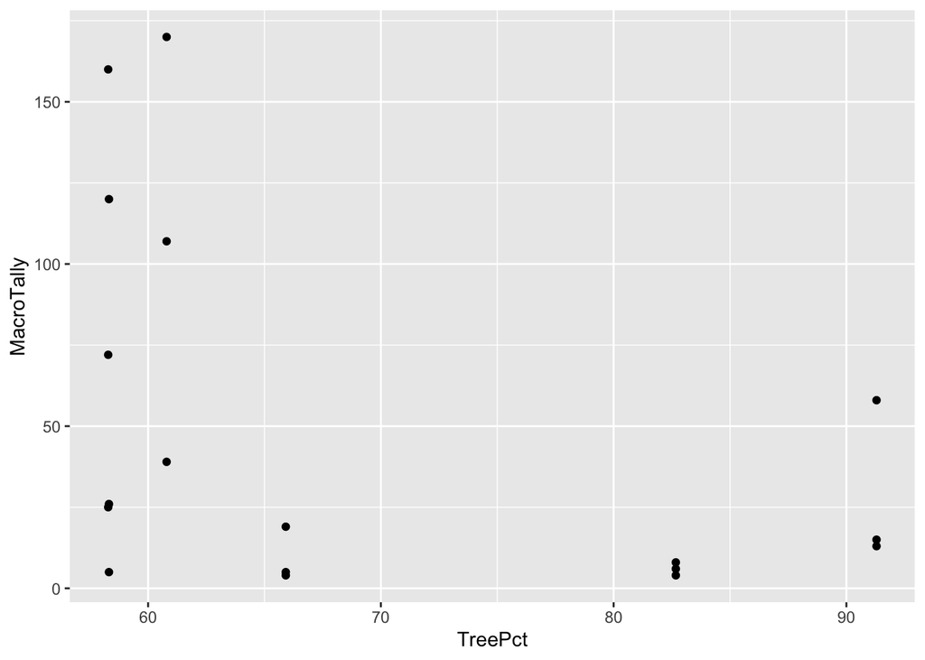

```r
ggplot(data=FinalDataFrameHABITAT,mapping=aes(x=TreePct,y=MacroTally))+geom_point()
```

Question 3- Does the biomass and functional feeding group diversity of macroinvertebrates in restored streams depend on the surrounding land use? Independent: Land Use variables Dependent: TotalMass, EPTAsPct, NumFFG, FFGDiversity (Quantitative vs. Quantitative- needs Spearman rank correlation

```r
cor.test(x=FinalDataFrameHABITAT$TreePct,y=FinalDataFrameHABITAT$TotalMass,method='spearman')
```

```
##
##  Spearman's rank correlation rho
##
## data:  FinalDataFrameHABITAT$TreePct and FinalDataFrameHABITAT$TotalMass
## S = 1233.3, p-value = 0.2735
## alternative hypothesis: true rho is not equal to 0
## sample estimates:
##        rho
## -0.2727487
```

```r
cor.test(x=FinalDataFrameHABITAT$TreePct,y=FinalDataFrameHABITAT$EPTAsPct,method='spearman')
```

```
##
##  Spearman's rank correlation rho
##
## data:  FinalDataFrameHABITAT$TreePct and FinalDataFrameHABITAT$EPTAsPct
## S = 1193.6, p-value = 0.3547
## alternative hypothesis: true rho is not equal to 0
## sample estimates:
##       rho
## -0.231781
```

```r
cor.test(x=FinalDataFrameHABITAT$TreePct,y=FinalDataFrameHABITAT$ShannonDiversity,method='spearman')
```

```
##
##  Spearman's rank correlation rho
##
## data:  FinalDataFrameHABITAT$TreePct and FinalDataFrameHABITAT$ShannonDiversity
## S = 1239.5, p-value = 0.2619
## alternative hypothesis: true rho is not equal to 0
## sample estimates:
##        rho
## -0.2791629
```

```r
cor.test(x=FinalDataFrameHABITAT$TreePct,y=FinalDataFrameHABITAT$FFGDiversity,method='spearman')
```

```
##
##  Spearman's rank correlation rho
##
## data:  FinalDataFrameHABITAT$TreePct and FinalDataFrameHABITAT$FFGDiversity
## S = 1203, p-value = 0.3343
## alternative hypothesis: true rho is not equal to 0
## sample estimates:
##        rho
## -0.2415229
```

```r
cor.test(x=FinalDataFrameHABITAT$VegPct,y=FinalDataFrameHABITAT$TotalMass,method='spearman')
```

```
##
##  Spearman's rank correlation rho
##
## data:  FinalDataFrameHABITAT$VegPct and FinalDataFrameHABITAT$TotalMass
## S = 1433.8, p-value = 0.04397
## alternative hypothesis: true rho is not equal to 0
## sample estimates:
##        rho
## -0.4796615
```

```r
cor.test(x=FinalDataFrameHABITAT$VegPct,y=FinalDataFrameHABITAT$EPTAsPct,method='spearman')
```

```
##
##  Spearman's rank correlation rho
##
## data:  FinalDataFrameHABITAT$VegPct and FinalDataFrameHABITAT$EPTAsPct
## S = 1117.6, p-value = 0.5436
## alternative hypothesis: true rho is not equal to 0
## sample estimates:
##       rho
## -0.153332
```

```r
cor.test(x=FinalDataFrameHABITAT$VegPct,y=FinalDataFrameHABITAT$ShannonDiversity,method='spearman')
```

```
##
##  Spearman's rank correlation rho
##
## data:  FinalDataFrameHABITAT$VegPct and FinalDataFrameHABITAT$ShannonDiversity
## S = 1409.7, p-value = 0.05791
## alternative hypothesis: true rho is not equal to 0
## sample estimates:
##        rho
## -0.4548159
```

```r
cor.test(x=FinalDataFrameHABITAT$VegPct,y=FinalDataFrameHABITAT$FFGDiversity,method='spearman')
```

```
##
##  Spearman's rank correlation rho
##
## data:  FinalDataFrameHABITAT$VegPct and FinalDataFrameHABITAT$FFGDiversity
## S = 1373.2, p-value = 0.08499
## alternative hypothesis: true rho is not equal to 0
## sample estimates:
##       rho
## -0.417176
```

```r
cor.test(x=FinalDataFrameHABITAT$PerviousPct,y=FinalDataFrameHABITAT$TotalMass,method='spearman')
```

```
##
##  Spearman's rank correlation rho
##
## data:  FinalDataFrameHABITAT$PerviousPct and FinalDataFrameHABITAT$TotalMass
## S = 1433.8, p-value = 0.04397
## alternative hypothesis: true rho is not equal to 0
## sample estimates:
##        rho
## -0.4796615
```

```r
cor.test(x=FinalDataFrameHABITAT$PerviousPct,y=FinalDataFrameHABITAT$EPTAsPct,method='spearman')
```

```
##
##  Spearman's rank correlation rho
##
## data:  FinalDataFrameHABITAT$PerviousPct and FinalDataFrameHABITAT$EPTAsPct
## S = 1117.6, p-value = 0.5436
## alternative hypothesis: true rho is not equal to 0
## sample estimates:
##       rho
## -0.153332
```

```r
cor.test(x=FinalDataFrameHABITAT$PerviousPct,y=FinalDataFrameHABITAT$ShannonDiversity,method='spearman')
```

```
##
##  Spearman's rank correlation rho
##
## data:  FinalDataFrameHABITAT$PerviousPct and FinalDataFrameHABITAT$ShannonDiversity
## S = 1409.7, p-value = 0.05791
## alternative hypothesis: true rho is not equal to 0
## sample estimates:
##        rho
## -0.4548159
```

```r
cor.test(x=FinalDataFrameHABITAT$PerviousPct,y=FinalDataFrameHABITAT$FFGDiversity,method='spearman')
```

```
##
##  Spearman's rank correlation rho
##
## data:  FinalDataFrameHABITAT$PerviousPct and FinalDataFrameHABITAT$FFGDiversity
## S = 1373.2, p-value = 0.08499
## alternative hypothesis: true rho is not equal to 0
## sample estimates:
##       rho
## -0.417176
```

##PART THREE VISUALIZING WITH GRAPHS Graphs to help answer Question 1

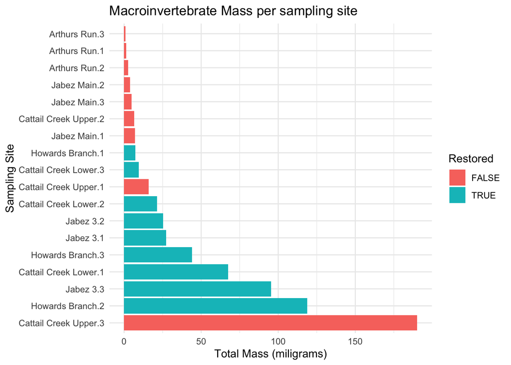

```r
ggplot(FinalDataFrameHABITAT,aes(x=reorder(SiteName,-TotalMass),y=TotalMass,fill=Restored))+geom_bar(stat="identity")+coord_flip()+xlab("Sampling Site")+ylab("Total Mass (miligrams)")+ggtitle("Macroinvertebrate Mass per sampling site")+theme_minimal()
```

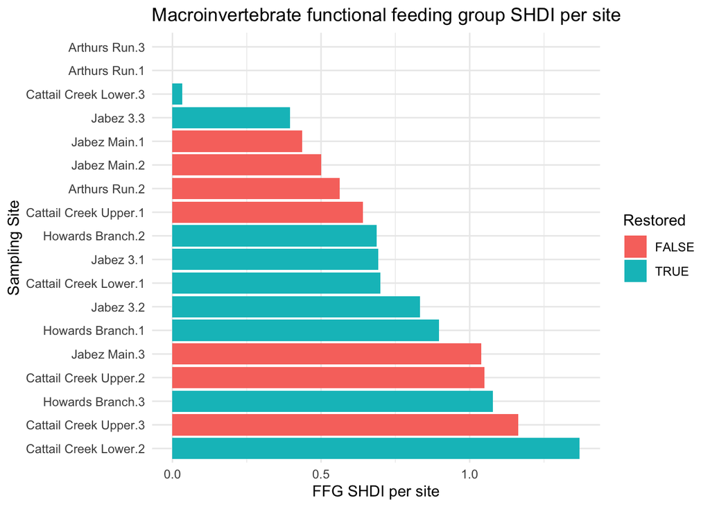

```r
ggplot(FinalDataFrameHABITAT,aes(x=reorder(SiteName,-FFGDiversity),y=FFGDiversity,fill=Restored))+geom_bar(stat="identity")+coord_flip()+xlab("Sampling Site")+ylab("FFG SHDI per site")+ggtitle("Macroinvertebrate functional feeding group SHDI per site")+theme_minimal()
```

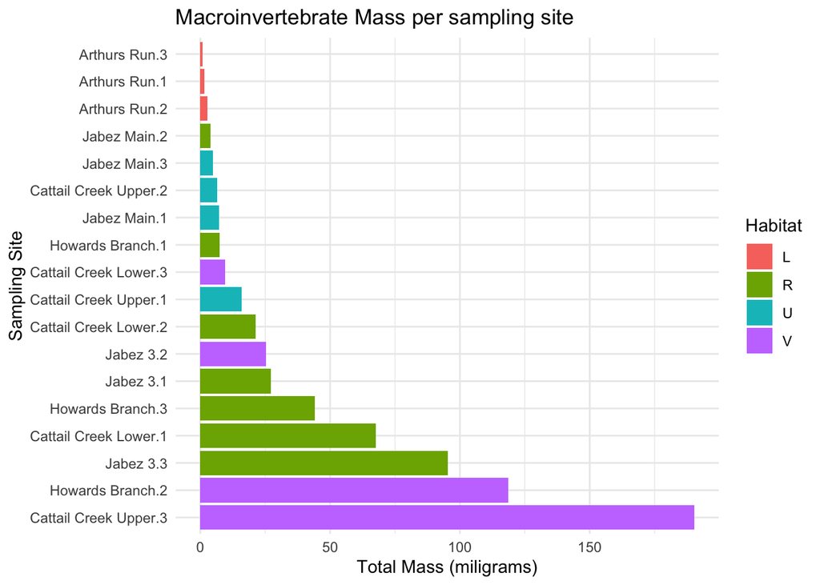

```r
ggplot(FinalDataFrameHABITAT,aes(x=reorder(SiteName,-TotalMass),y=TotalMass,fill=Habitat))+geom_bar(stat="identity")+coord_flip()+xlab("Sampling Site")+ylab("Total Mass (miligrams)")+ggtitle("Macroinvertebrate Mass per sampling site")+theme_minimal()
```

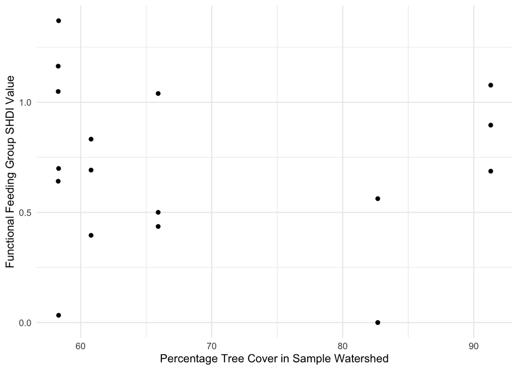

```r
ggplot(FinalDataFrameHABITAT,aes(x=TreePct,y=FFGDiversity))+geom_point()+xlab("Percentage Tree Cover in Sample Watershed")+ylab("Functional Feeding Group SHDI Value")+theme_minimal()
```

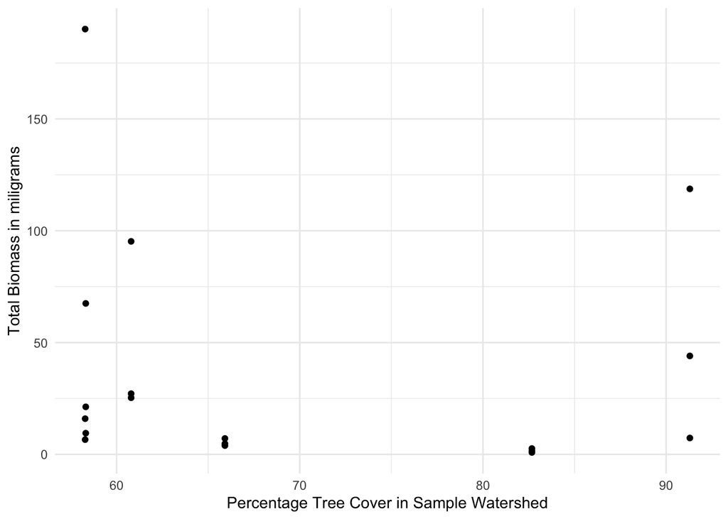

```r
ggplot(FinalDataFrameHABITAT,aes(x=TreePct,y=TotalMass))+geom_point()+xlab("Percentage Tree Cover in Sample Watershed")+ylab("Total Biomass in miligrams")+theme_minimal()
```